# Think Believe 1 (forced choice): Religious affiliation and religiosity

## Religiosity

### `thb2_demo_regp`: “Are you a part of any religious group?”

```
Factor `thb2_demo_regp` contains implicit NA, consider using `forcats::fct_explicit_na`
```

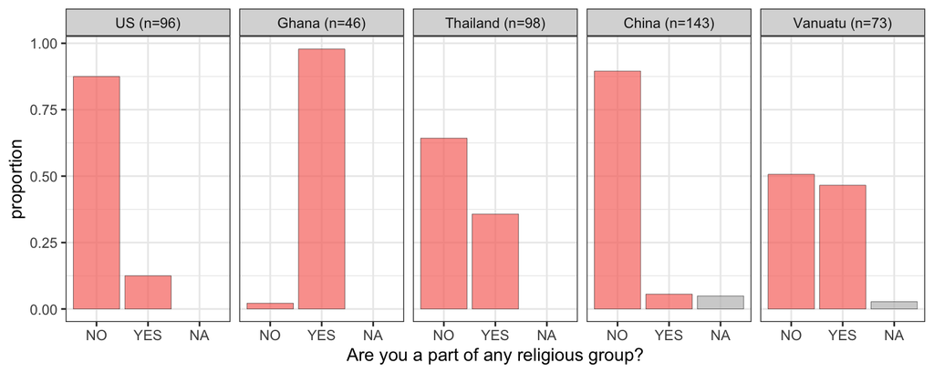

### `thb2_demo_rely`: “From 1 to 7, how religious are you? (1 = not religious at all, 7 = extremely religious)”

Seems to have been omitted in Thailand?

```
Factor `thb2_demo_rely` contains implicit NA, consider using `forcats::fct_explicit_na`
```

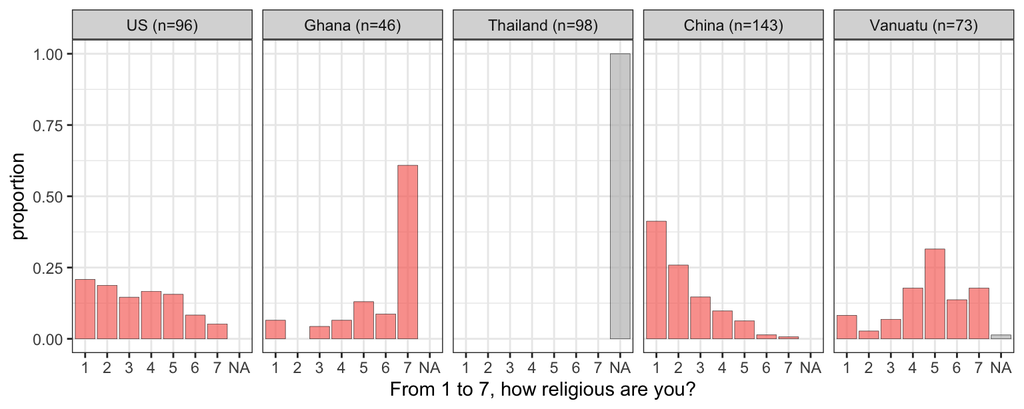

### `thb2_demo_impr`: “From 1 to 7, how important to you is your religious practice? (1 = not important at all, 7 = of utmost importance)”

Seems to have been omitted in Thailand?

```
Factor `thb2_demo_impr` contains implicit NA, consider using `forcats::fct_explicit_na`
```

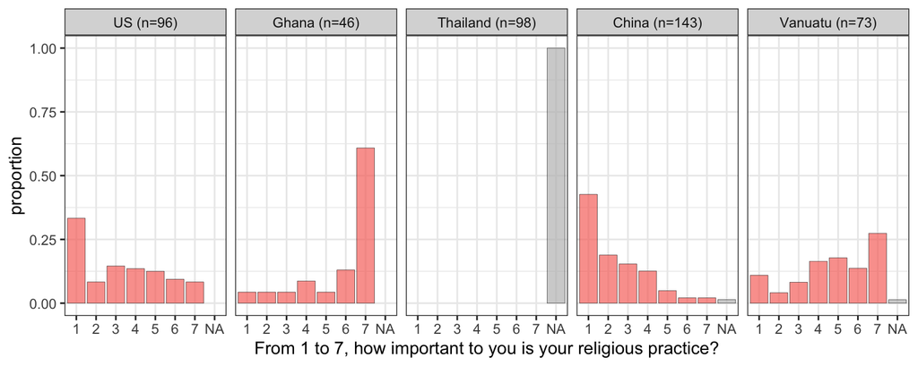

### `thb2_demo_wors`: “How often do you attend places of worship?”

```
Factor `thb2_demo_wors` contains implicit NA, consider using `forcats::fct_explicit_na`
```

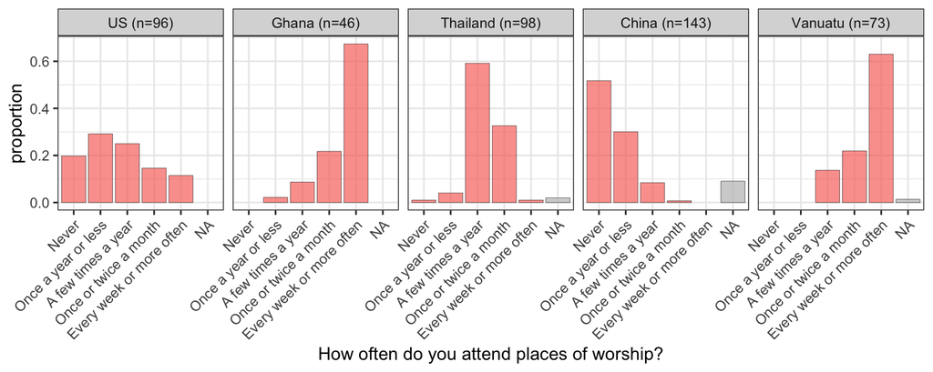

### `thb2_demo_bgod`: “What best describes your level of belief in God?”

```
Factor `thb2_demo_bgod` contains implicit NA, consider using `forcats::fct_explicit_na`
```

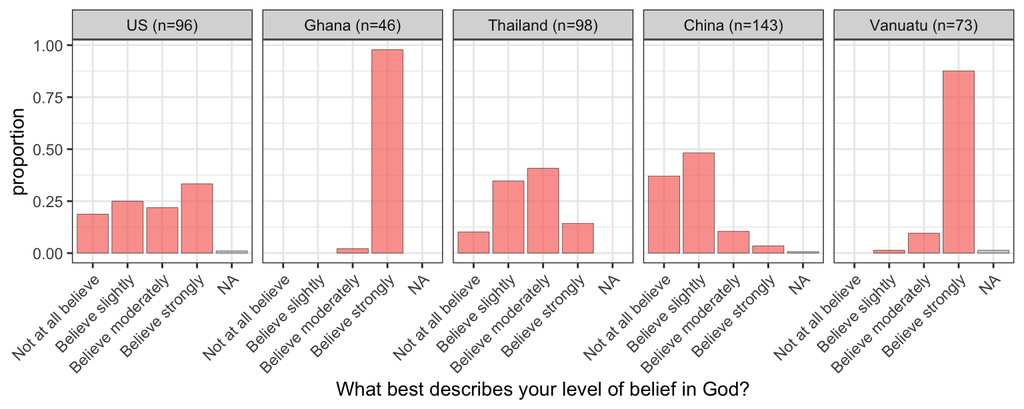

### `thb2_demo_bbuh`: “What best describes your level of belief in Buddha?”

```
Factor `thb2_demo_bbuh` contains implicit NA, consider using `forcats::fct_explicit_na`
```

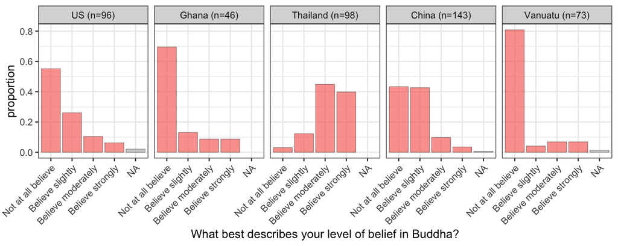

### `thb2_demo_bosp`: “What best describes your level of belief in another spiritual being (other than God or Buddha)?”

```
Factor `thb2_demo_bosp` contains implicit NA, consider using `forcats::fct_explicit_na`
```

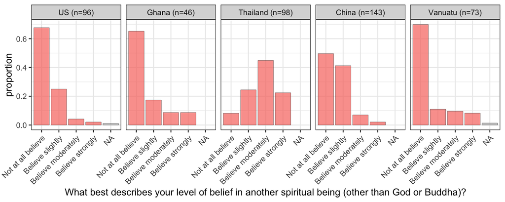

### `thb2_demo_atsn`: "What best describes your attitude towards the supernatural?

```
Factor `thb2_demo_atsn` contains implicit NA, consider using `forcats::fct_explicit_na`
```

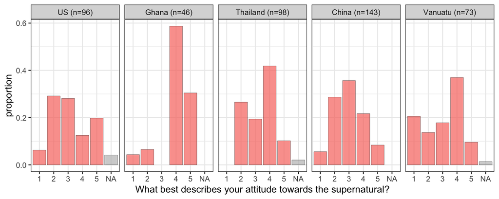

Response options:

1. “There is no such thing as supernatural forces or beings”
2. “We cannot know if there are supernatural forces and beings”
3. “There might be supernatural forces and beings”
4. “Supernatural forces and beings exist but we cannot know what they are like”
5. “There definitely are supernatural forces and beings”

### `thb2_demo_imsn`: “From 1 to 7, how important to you is your attitude toward the supernatural? (1 = not important at all, 7 = of utmost importance)”

```
Factor `thb2_demo_imsn` contains implicit NA, consider using `forcats::fct_explicit_na`
```

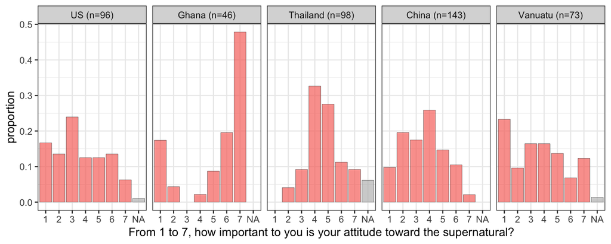

# Analyses

Now, let’s look at how responses to our think/believe questions might have varied depending on religion/religiosity. For now, I’ll just focus on a couple of variables that seem to have been answered in reasonable ways.

## Religiosity

### `thb2_demo_rely`: “From 1 to 7, how religious are you? (1 = not religious at all, 7 = extremely religious)”

```r
r2.6 <- lmer(believeX ~ super_cat * country * thb2_demo_rely_num
             + (1 + super_cat | thb2_subj) + (1 | question),
             data = d2_long %>%
               filter(country != "Thailand") %>%
               mutate(thb2_demo_rely_num = scale(thb2_demo_rely_num)),
             contrasts = list(country = "contr.sum"))
```

[output not shown]

| Parameter | β | β' | β'' | Std. Err. | df | t | p |  |
| --- | --- | --- | --- | --- | --- | --- | --- | --- |
| Intercept | 0.18 | - | - | 0.02 | 97.46 | 9.96 | <0.001 | *** |
| Category (religious) | 0.13 | 0.34 | 0.34 | 0.02 | 70.82 | 7.99 | <0.001 | *** |
| Country (US) | 0.10 | 0.18 | 0.18 | 0.02 | 280.23 | 5.20 | <0.001 | *** |
| Country (Ghana) | -0.11 | -0.17 | -0.17 | 0.03 | 289.15 | -3.68 | <0.001 | *** |
| Country (China) | 0.03 | 0.06 | 0.06 | 0.02 | 274.89 | 1.41 | 0.160 |  |
| How religious are you? | 0.00 | 0.00 | 0.00 | 0.01 | 282.29 | -0.09 | 0.925 |  |
| Category (religious) × Country (US) | 0.07 | 0.14 | 0.14 | 0.02 | 286.88 | 4.72 | <0.001 | *** |
| Category (religious) × Country (Ghana) | -0.08 | -0.12 | -0.12 | 0.03 | 301.47 | -3.11 | 0.002 | ** |
| Category (religious) × Country (China) | 0.04 | 0.08 | 0.08 | 0.02 | 279.25 | 2.25 | 0.025 | * |
| Category (religious) × How religious are you? | -0.01 | -0.01 | -0.01 | 0.01 | 290.48 | -0.50 | 0.615 |  |
| Country (US) × How religious are you? | 0.00 | 0.01 | 0.01 | 0.02 | 278.83 | 0.20 | 0.844 |  |
| Country (Ghana) × How religious are you? | 0.03 | 0.05 | 0.05 | 0.02 | 288.04 | 1.10 | 0.273 |  |
| Country (China) × How religious are you? | -0.01 | -0.01 | -0.01 | 0.02 | 273.72 | -0.40 | 0.690 |  |
| Category (religious) × Country (US) × How religious are you? | 0.00 | 0.00 | 0.00 | 0.02 | 284.45 | -0.18 | 0.861 |  |
| Category (religious) × Country (Ghana) × How religious are you? | 0.01 | 0.02 | 0.02 | 0.02 | 299.67 | 0.60 | 0.549 |  |
| Category (religious) × Country (China) × How religious are you? | 0.00 | 0.00 | 0.00 | 0.02 | 277.30 | 0.00 | 0.998 |  |

This analysis suggests that greater religiosity was NOT associated with an increased distinction between religious and fact questions. (Note that this analysis omits participants from Thailand, who did not answer this question about religiosity.)

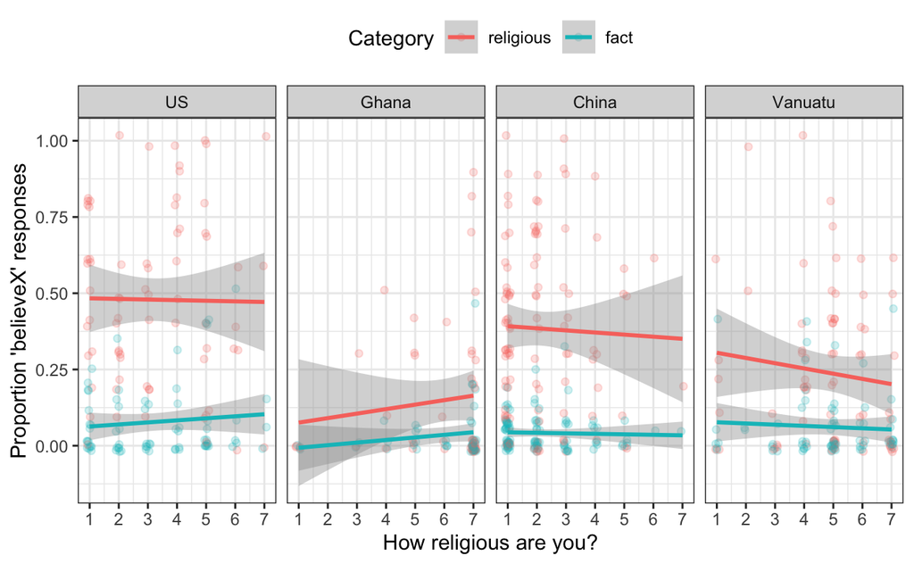

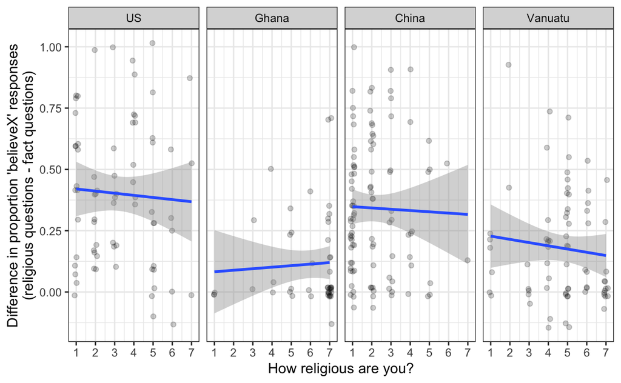

### `thb2_demo_impr`: “From 1 to 7, how important to you is your religious practice? (1 = not important at all, 7 = of utmost importance)”

```r
r2.7 <- lmer(believeX ~ super_cat * country * thb2_demo_impr_num
             + (1 + super_cat | thb2_subj) + (1 | question),
             data = d2_long %>%
               filter(country != "Thailand") %>%
               mutate(thb2_demo_impr_num = scale(thb2_demo_impr_num)),
             contrasts = list(country = "contr.sum"))
```

[output not shown]

| Parameter | β | β' | β'' | Std. Err. | df | t | p |  |
| --- | --- | --- | --- | --- | --- | --- | --- | --- |
| Intercept | 0.18 | - | - | 0.02 | 90.16 | 10.16 | <0.001 | *** |
| Category (religious) | 0.12 | 0.33 | 0.33 | 0.02 | 65.49 | 7.84 | <0.001 | *** |
| Country (US) | 0.09 | 0.17 | 0.17 | 0.02 | 278.70 | 5.10 | <0.001 | *** |
| Country (Ghana) | -0.10 | -0.15 | -0.15 | 0.03 | 287.71 | -3.38 | <0.001 | *** |
| Country (China) | 0.04 | 0.07 | 0.07 | 0.02 | 274.01 | 1.85 | 0.066 |  |
| How important is your religious practice? | 0.00 | 0.00 | 0.00 | 0.01 | 280.79 | -0.03 | 0.976 |  |
| Category (religious) × Country (US) | 0.08 | 0.14 | 0.14 | 0.02 | 285.40 | 4.93 | <0.001 | *** |
| Category (religious) × Country (Ghana) | -0.08 | -0.12 | -0.12 | 0.02 | 300.33 | -3.24 | 0.001 | ** |
| Category (religious) × Country (China) | 0.05 | 0.10 | 0.10 | 0.02 | 278.70 | 2.97 | 0.003 | ** |
| Category (religious) × How important is your religious practice? | 0.00 | 0.00 | 0.00 | 0.01 | 289.09 | -0.04 | 0.966 |  |
| Country (US) × How important is your religious practice? | -0.02 | -0.03 | -0.03 | 0.02 | 276.18 | -0.95 | 0.345 |  |
| Country (Ghana) × How important is your religious practice? | 0.01 | 0.03 | 0.03 | 0.02 | 286.73 | 0.61 | 0.544 |  |
| Country (China) × How important is your religious practice? | 0.00 | 0.00 | 0.00 | 0.02 | 272.60 | -0.07 | 0.948 |  |
| Category (religious) × Country (US) × How important is your religious practice? | -0.02 | -0.04 | -0.04 | 0.02 | 281.17 | -1.58 | 0.115 |  |
| Category (religious) × Country (Ghana) × How important is your religious practice? | 0.01 | 0.02 | 0.02 | 0.02 | 298.72 | 0.62 | 0.534 |  |
| Category (religious) × Country (China) × How important is your religious practice? | 0.00 | 0.00 | 0.00 | 0.02 | 276.37 | 0.00 | 0.998 |  |

This analysis suggests that more importance placed on religious practice was NOT associated with an increased distinction between religious and fact questions. (Note that this analysis omits participants from Thailand, who did not answer this question about religiosity.)

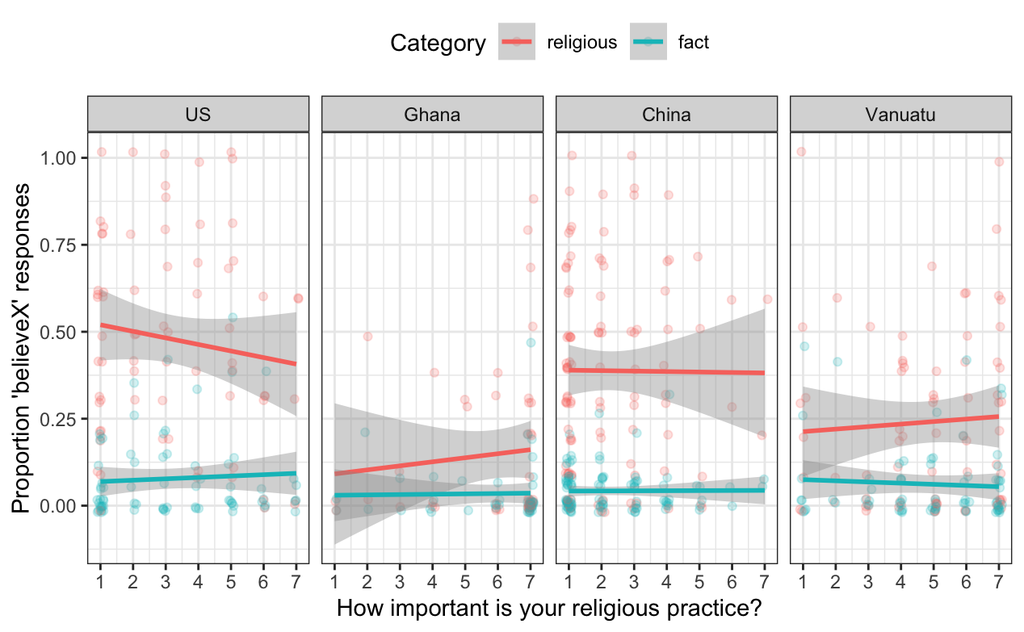

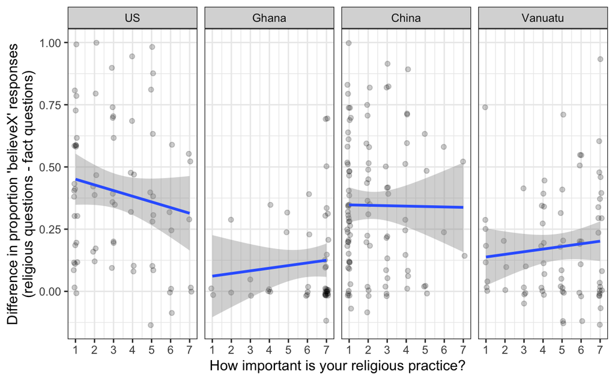

### `thb2_demowors`: “How often do you attend places of worship?”

```r
r2.8 <- lmer(believeX ~ super_cat * country * thb2_demo_wors_num
             + (1 + super_cat | thb2_subj) + (1 | question),
             data = d2_long %>%
               mutate(thb2_demo_wors_num = scale(thb2_demo_wors_num)))
```

| Parameter | β | β' | β'' | Std. Err. | df | t | p |  |
| --- | --- | --- | --- | --- | --- | --- | --- | --- |
| Intercept | 0.17 | - | - | 0.02 | 193.18 | 8.57 | <0.001 | *** |
| Category (religious) | 0.13 | 0.33 | 0.33 | 0.02 | 130.12 | 7.18 | <0.001 | *** |
| Country (Gh.) | -0.13 | -0.19 | -0.19 | 0.05 | 371.24 | -2.74 | 0.006 | ** |
| Country (Th.) | 0.01 | 0.02 | 0.02 | 0.02 | 368.78 | 0.60 | 0.547 |  |
| Country (Ch.) | 0.05 | 0.09 | 0.09 | 0.03 | 353.94 | 1.32 | 0.188 |  |
| Country (Vt.) | -0.03 | -0.05 | -0.05 | 0.04 | 370.89 | -0.79 | 0.432 |  |
| How often do you attend places of worship? | 0.02 | 0.05 | 0.05 | 0.02 | 367.10 | 1.10 | 0.271 |  |
| Category (religious) × Country (Gh.) | -0.09 | -0.14 | -0.14 | 0.04 | 384.82 | -2.40 | 0.017 | * |
| Category (religious) × Country (Th.) | 0.01 | 0.01 | 0.01 | 0.02 | 380.61 | 0.34 | 0.731 |  |
| Category (religious) × Country (Ch.) | 0.05 | 0.09 | 0.09 | 0.03 | 355.77 | 1.68 | 0.093 |  |
| Category (religious) × Country (Vt.) | -0.04 | -0.06 | -0.06 | 0.03 | 384.23 | -1.13 | 0.259 |  |
| Category (religious) × How often do you attend places of worship? | 0.01 | 0.01 | 0.01 | 0.01 | 377.70 | 0.40 | 0.686 |  |
| Country (Gh.) × How often do you attend places of worship? | 0.02 | 0.04 | 0.04 | 0.04 | 371.13 | 0.61 | 0.544 |  |
| Country (Th.) × How often do you attend places of worship? | 0.01 | 0.01 | 0.01 | 0.03 | 370.86 | 0.31 | 0.754 |  |
| Country (Ch.) × How often do you attend places of worship? | 0.00 | -0.01 | -0.01 | 0.03 | 355.06 | -0.14 | 0.890 |  |
| Country (Vt.) × How often do you attend places of worship? | -0.01 | -0.02 | -0.02 | 0.03 | 370.81 | -0.33 | 0.745 |  |
| Category (religious) × Country (Gh.) × How often do you attend places of worship? | 0.01 | 0.02 | 0.02 | 0.03 | 384.62 | 0.45 | 0.653 |  |
| Category (religious) × Country (Th.) × How often do you attend places of worship? | 0.02 | 0.02 | 0.02 | 0.03 | 384.16 | 0.62 | 0.539 |  |
| Category (religious) × Country (Ch.) × How often do you attend places of worship? | 0.00 | 0.00 | 0.00 | 0.03 | 357.55 | 0.01 | 0.994 |  |
| Category (religious) × Country (Vt.) × How often do you attend places of worship? | -0.01 | -0.01 | -0.01 | 0.03 | 384.07 | -0.25 | 0.799 |  |

This analysis suggests that frequency of attendence was NOT associated with an increased distinction between religious and fact questions.

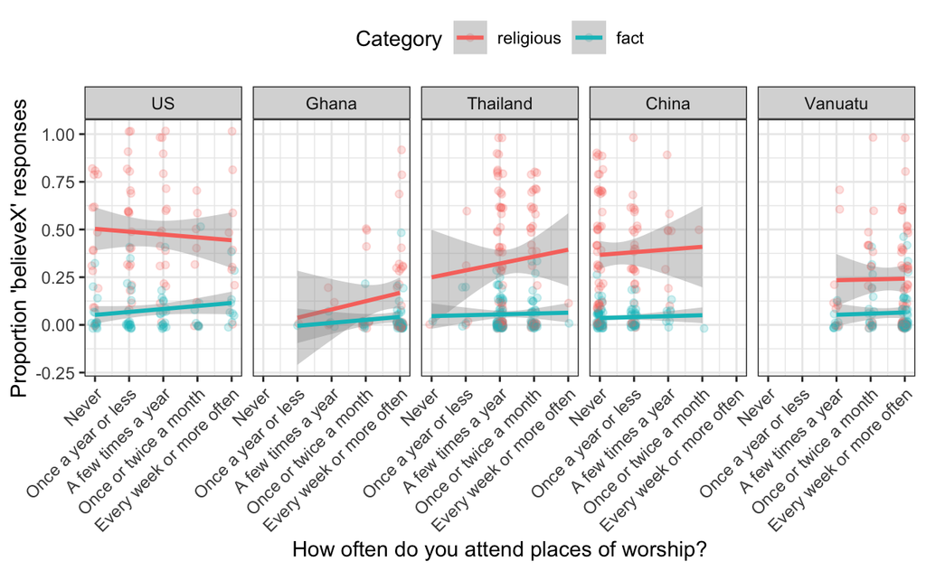

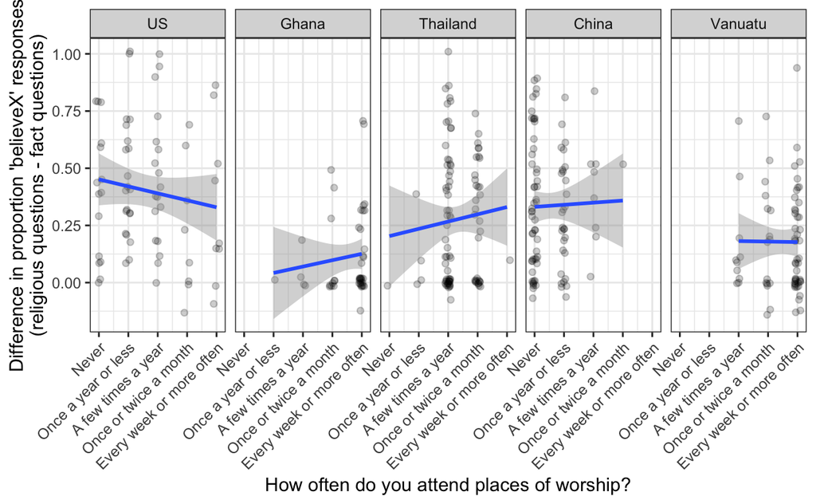